# Nonlinear regression

```r
library(tidyverse)
library(caret)
library(AppliedPredictiveModeling)
library(doParallel)
library(earth)
library(kernlab)
library(mlbench)
```

# Computing

## Neural networks

1. Remove highly correlated predictors
2. Preprocessing: center and scale

Yes, averaged models or neural nets in general are very susceptible to highly correlated variables. Therefore, it is necessary to remove highly correlated variables.

```r
data(solubility)
```

```r
# Finding correlations

too_high <- findCorrelation(cor(solTrainXtrans), 0.75)

length(too_high)
# 87 variables need to be removed
train <- solTrainXtrans[, -too_high]
test <- solTestXtrans[, -too_high]

train_sol <- solTrainY
test_sol <- solTestY
```

Alright, all the data is ready to feed into the model.

Now let’s create some grid search parameters for the neural net.

```r
# This is essentially a cartesian product
nnet_grid <- expand.grid(.decay = c(0, 0.01, 0.1),
                         .size = c(1:10),
                         .bag = FALSE)


indx <- createFolds(train_sol, returnTrain = TRUE)
ctrl <- trainControl(method = "cv", index = indx)
```

```r
workers=makeCluster(16,type="SOCK")
registerDoParallel(workers)
```

```r
nnet_tune <- train(train, train_sol,
                   method = "avNNet",
                   tuneGrid = nnet_grid,
                   trControl = ctrl,
                   preProc = c("center", "scale"),
                   linout = T,
                   trace = T,
                   MaxNWts = 10 * (ncol(train) + 1) + 10 + 1,
                   maxit = 100)
```

Lesson learned: Neural networks take forever to finish

```r
nnet_tune
```

## Random Forest

```r
ranf_model <- train(train, train_sol,
                    method = "rf",
                    tuneLength = 10,
                    trControl = trainControl(method = "cv", number = 10))

ranf_model
```

Actually, my random forest does a better job than the neural network. This is pretty amazing. I will have to try these methods on my Titanic dataset.

## MARS

Do I need to preprocess for MARS? The author doesn’t.

```r
mars_grid <- expand.grid(.degree = 1:2, .nprune = 2:38)

mars_model <- train(solTrainXtrans, train_sol,
                    method = "earth",
                    tuneGrid = mars_grid,
                    trControl = trainControl(method = "cv", number = 10))

mars_model
```

This is even better than the random forest model. What is going on? MARS models are not actually crap?

## Variable importance

```r
# Neural net
varImp(nnet_tune)
```

```r
# Random forest
varImp(mars_model)
```

They pick completely different variables.

## SVM

Do I need to remove correlated predictors?

```r
svm_model <- train(solTrainXtrans, train_sol,
                   method = "svmRadial",
                   preproc = c("center", "scale"),
                   tuneLength = 14,
                   trControl = trainControl(method = "cv"))

svm_model
```

You have to be kidding. This model is the best yet. When is this going to stop?

What I learnt is that neural nets are difficult to run, random forests and SVM are easy, MARS is also easy.

```r
varImp(svm_model)
```

## KNN

For this model, I will remove highly correlated variables.

```r
knn_model <- train(train, train_sol,
                   method = "knn",
                   preProc = c("center", "scale"),
                   trControl = trainControl(method = "cv", number = 10),
                   tuneLength = 20)

knn_model
```

This model is kinda crap compared to the others that came before.

```r
varImp(knn_model)
```

# Exercises

7.1 Support vector machine

```r
x <- runif(100, min = 2, max = 10)
y <- sin(x) + rnorm(length(x)) * .25
sinData <- data.frame(x = x, y = y)

plot(x, y)

## Create a grid of x values to use for prediction
data_grid <- data.frame(x = seq(2, 10, length = 100))
```

1. Fit different

```r
rbfSVM <- ksvm(x = x, y = y, data = sinData,
               kernel ="rbfdot", kpar = "automatic",
               C = 1000000, epsilon = 0.1)

modelPrediction <- predict(rbfSVM, newdata = data_grid)

## This is a matrix with one column. We can plot the
## model predictions by adding points to the previous plot
plot(x, y)
points(x = data_grid$x, y = modelPrediction[,1],
       type = "l", col = "blue")
```

There is a tiny possibility that maybe I overfit my model a little bit. Just a tiny bit. Nothing too serious.

```r
rbfSVM <- ksvm(x = x, y = y, data = sinData,
               kernel ="rbfdot", kpar = "automatic",
               C = 0.0000000001, epsilon = 0.1)

modelPrediction <- predict(rbfSVM, newdata = data_grid)

## This is a matrix with one column. We can plot the
## model predictions by adding points to the previous plot
plot(x, y)
points(x = data_grid$x, y = modelPrediction[,1],
       type = "l", col = "blue")
```

SVM with the lowest cost parameter is essentially a linear model.

```r
rbfSVM <- ksvm(x = x, y = y, data = sinData,
               kernel ="rbfdot", kpar = list(sigma = 6),
               C = 0.25, epsilon = 0.1)

modelPrediction <- predict(rbfSVM, newdata = data_grid)

## This is a matrix with one column. We can plot the
## model predictions by adding points to the previous plot
plot(x, y)
points(x = data_grid$x, y = modelPrediction[,1],
       type = "l", col = "blue")
```

This one looks quite good. I’m essentially doing manual grid search for the best parameters. The author wants me to get an intuitive understanding of what these do. Epsilon flattens the line.

This works fine. I can’t really tell the difference between different parameters. Both sigma and the cost go from 0 = underfitting / linear model to overfitting. They are able to capture nonlinear relationships.

7.2 Friedman benchmark datasets

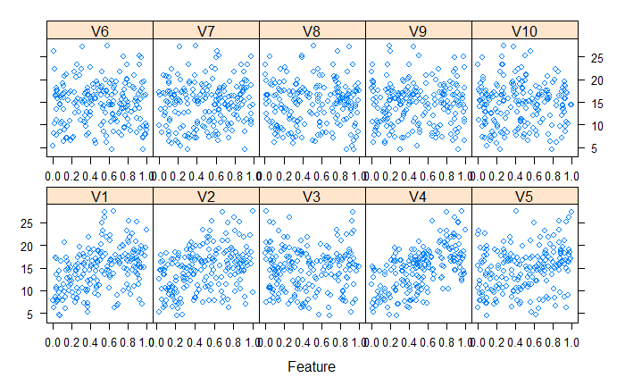

```r
training_data <- mlbench.friedman1(200, sd = 1)
training_data$x <- as.data.frame(training_data$x)

featurePlot(training_data$x, training_data$y)
```

Ok, what is this supposed to mean?

```r
test_data <- mlbench.friedman1(5000, sd = 1)
test_data$x <- data.frame(test_data$x)
```

Let’s check for highly correlated variables. That’s what we did in computing.

```r
corrplot::corrplot(cor(training_data$x), method = "number")
```

It looks great, there is no need to remove correlated predictors, I have been handed clean data.

**KNN**

```r
## Tune example model on the data
## I only have 200 observations, so cross-validate heavily
knn_model <- train(training_data$x, training_data$y,
                   method = "knn",
                   preProc = c("center", "scale"),
                   tuneLength = 10,
                   trControl = trainControl(method = "repeatedcv",
                                            number = 10,
                                            repeats = 10))

knn_model
```

```
k-Nearest Neighbors

200 samples
 10 predictor

Pre-processing: centered (10), scaled (10)
Resampling: Cross-Validated (10 fold, repeated 10 times)
Summary of sample sizes: 180, 180, 180, 180, 180, 180, ...
Resampling results across tuning parameters:

  k   RMSE      Rsquared   MAE
   5  3.446849  0.4950532  2.778436
   7  3.419052  0.5245138  2.768059
   9  3.386340  0.5547645  2.724816
  11  3.358698  0.5763990  2.691344
  13  3.363210  0.5900317  2.699239
  15  3.345236  0.6101872  2.681027
  17  3.362463  0.6203025  2.703659
  19  3.370320  0.6292053  2.723325
  21  3.396103  0.6308168  2.749398
  23  3.425864  0.6319567  2.770538

RMSE was used to select the optimal model using the smallest value.
The final value used for the model was k = 15.
```

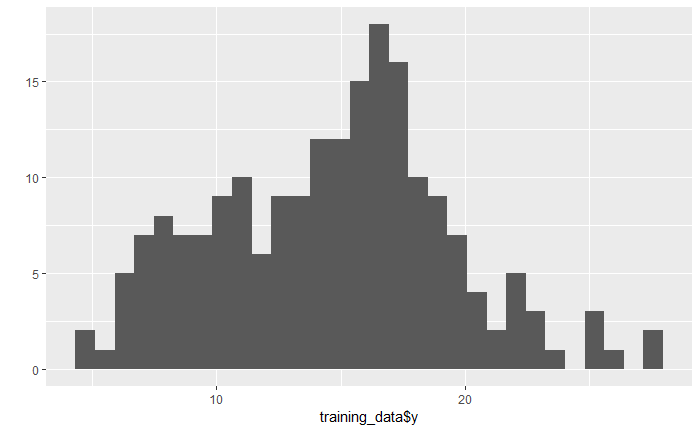

```r
qplot(training_data$y)
```

```r
summary(training_data$y)
```

```
   Min. 1st Qu.  Median    Mean 3rd Qu.    Max.
  4.565  10.975  15.168  14.663  17.515  27.404
```

It’s not horrible but also not very good.

```r
2.53 / (max(training_data$y) - min(training_data$y)) * 100
```

```
[1] 11.07742
```

It tells us about 10% of the range. It could be improved.

**Random Forest**

```r
workers = makeCluster(detectCores(), type = "SOCK")
registerDoParallel(workers)

ranf_model <- train(training_data$x, training_data$y,
                    method = "rf",
                    tuneLength = 5,
                    verboseIter = T,
                    trainCtrl = trainControl(method = "repeatedcv",
                                             number = 10,
                                             repeats = 10))
```

That was pretty quick. I’m pushing this poor T420 with these full CPU load parallel model training processes.

```r
ranf_model
```

```
Random Forest

200 samples
 10 predictor

No pre-processing
Resampling: Bootstrapped (25 reps)
Summary of sample sizes: 200, 200, 200, 200, 200, 200, ...
Resampling results across tuning parameters:

  mtry  RMSE      Rsquared   MAE
   2    2.976867  0.7634491  2.361068
   4    2.619464  0.7740049  2.068439
   6    2.513961  0.7643413  1.979299
   8    2.499822  0.7515567  1.973669
  10    2.526318  0.7365519  1.992877

RMSE was used to select the optimal model using the smallest value.
The final value used for the model was mtry = 8.
```

Much better than KNN. Yeah, KNN was crap before and crap now.

**SVM**

This one is a heavy-hitter. Let’s see what it’s capable of.

```r
svm_model <- train(training_data$x, training_data$y,
                   method = "svmRadial",
                   preProcess = c("center", "scale"),
                   tuneLength = 20,
                   trControl = trainControl(method = "repeatedcv",
                                            number = 10,
                                            repeats = 10))

svm_model
```

```
Support Vector Machines with Radial Basis Function Kernel

200 samples
 10 predictor

Pre-processing: centered (10), scaled (10)
Resampling: Cross-Validated (10 fold, repeated 10 times)
Summary of sample sizes: 180, 180, 180, 180, 180, 180, ...
Resampling results across tuning parameters:

  C          RMSE      Rsquared   MAE
       0.25  2.798315  0.7216838  2.238781
       0.50  2.544094  0.7398854  2.004701
       1.00  2.363242  0.7662332  1.869351
       2.00  2.215298  0.7903037  1.743328
       4.00  2.187342  0.7925754  1.732584
       8.00  2.156344  0.7976319  1.721759
      16.00  2.145942  0.7995547  1.711504
      32.00  2.145716  0.7995966  1.711326
      64.00  2.145716  0.7995966  1.711326
     128.00  2.145716  0.7995966  1.711326
     256.00  2.145716  0.7995966  1.711326
     512.00  2.145716  0.7995966  1.711326
    1024.00  2.145716  0.7995966  1.711326
    2048.00  2.145716  0.7995966  1.711326
    4096.00  2.145716  0.7995966  1.711326
    8192.00  2.145716  0.7995966  1.711326
   16384.00  2.145716  0.7995966  1.711326
   32768.00  2.145716  0.7995966  1.711326
   65536.00  2.145716  0.7995966  1.711326
  131072.00  2.145716  0.7995966  1.711326

Tuning parameter 'sigma' was held constant at a value of 0.07189731
RMSE was used to select the optimal model using the smallest value.
The final values used for the model were sigma = 0.07189731 and C = 32.
```

SVM training is so quick. Why is it so quick?

Yes, SVM is a real winner. I’m starting to like SVM a lot. They are really quick to train and they have pretty good accuracy. MAE of 1.71.

**OLS regression**

Let’s do this.

```r
ols_model <- train(training_data$x, training_data$y,
                   method = "lm",
                   preProcess = c("center", "scale"),
                   trControl = trainControl(method = "repeatedcv",
                                            number = 10,
                                            repeats = 10))
ols_model
```

```
Linear Regression

200 samples
 10 predictor

Pre-processing: centered (10), scaled (10)
Resampling: Cross-Validated (10 fold, repeated 10 times)
Summary of sample sizes: 180, 180, 180, 180, 180, 180, ...
Resampling results:

  RMSE      Rsquared   MAE
  2.588592  0.7069016  2.038772

Tuning parameter 'intercept' was held constant at a value of TRUE
```

It’s not very good but sort of on par with random forest.

**MARS**

This worked pretty well last time. Let’s check it out.

```r
mars_model <- train(training_data$x, training_data$y,
                    method = "earth",
                    tuneLength = 30,
                    trControl = trainControl(method = "repeatedcv",
                                             number = 10,
                                             repeats = 10))
mars_model
```

```
Multivariate Adaptive Regression Spline

200 samples
 10 predictor

No pre-processing
Resampling: Cross-Validated (10 fold, repeated 10 times)
Summary of sample sizes: 180, 180, 180, 180, 180, 180, ...
Resampling results across tuning parameters:

  nprune  RMSE      Rsquared   MAE
   2      3.753952  0.3773587  3.161545
   3      3.142871  0.5709543  2.507632
   4      2.548254  0.7229112  2.020313
   5      2.213860  0.7918646  1.745143
   6      2.066316  0.8195163  1.636873
   7      1.835659  0.8580359  1.441611
   8      1.762139  0.8692090  1.406540
   9      1.812992  0.8615429  1.441422
  10      1.838997  0.8580064  1.466284
  11      1.858229  0.8557901  1.484860
  12      1.874455  0.8537304  1.497504
  13      1.874865  0.8535235  1.496111
  14      1.881018  0.8524590  1.497128
  15      1.882907  0.8520130  1.500029
  16      1.882907  0.8520130  1.500029

Tuning parameter 'degree' was held constant at a value of 1
RMSE was used to select the optimal model using the smallest value.
The final values used for the model were nprune = 8 and degree = 1.
```

Damn. This is better than the SVM. These MARS models are really no joke. I never even heard of this model outside of statistical testbooks but these are good. Absolutely no joke.

It might be quite dataset dependent. Anyway, I will not disrespect MARS ever again.

**Neural Net**

i would rather not run it at home, my laptop won’t take it.

I pretty much ran out of model for these chapters. Let’s try one more thing.

**XGBoost**

```r
xgb_model
```

```
eXtreme Gradient Boosting

200 samples
 10 predictor

No pre-processing
Resampling: Cross-Validated (10 fold)
Summary of sample sizes: 180, 180, 180, 180, 180, 180, ...
Resampling results across tuning parameters:

  eta  max_depth  colsample_bytree  subsample  nrounds  RMSE      Rsquared   MAE
  0.3  1          0.6               0.500       50      2.111394  0.8024800  1.619154
  0.3  1          0.6               0.500      100      1.985458  0.8194417  1.518721
  0.3  1          0.6               0.500      150      1.995233  0.8183678  1.570244
  0.3  1          0.6               0.500      200      1.968312  0.8236602  1.553386
  0.3  1          0.6               0.500      250      2.021085  0.8159247  1.601481
  0.3  1          0.6               0.625       50      2.039336  0.8140132  1.605238
  0.3  1          0.6               0.625      100      1.949945  0.8252486  1.552020
  0.3  1          0.6               0.625      150      1.940605  0.8250126  1.545678
  0.3  1          0.6               0.625      200      1.955647  0.8208012  1.555096
  0.3  1          0.6               0.625      250      1.986000  0.8161530  1.586258
  0.3  1          0.6               0.750       50      2.014693  0.8147933  1.596564
  0.3  1          0.6               0.750      100      1.968097  0.8188688  1.536730
  0.3  1          0.6               0.750      150      1.965353  0.8193062  1.544668
  0.3  1          0.6               0.750      200      1.967099  0.8211041  1.557675
  0.3  1          0.6               0.750      250      1.950045  0.8242207  1.556774
  0.3  1          0.6               0.875       50      2.007369  0.8171984  1.569969
  0.3  1          0.6               0.875      100      1.917481  0.8261600  1.476912
  0.3  1          0.6               0.875      150      1.953067  0.8174038  1.519154
  0.3  1          0.6               0.875      200      1.961167  0.8176528  1.532641
  0.3  1          0.6               0.875      250      1.965952  0.8154006  1.545865
  0.3  1          0.6               1.000       50      1.971953  0.8284258  1.560674
  0.3  1          0.6               1.000      100      1.906741  0.8289392  1.508926
  0.3  1          0.6               1.000      150      1.927136  0.8251742  1.532778
  0.3  1          0.6               1.000      200      1.938553  0.8238415  1.543163
  0.3  1          0.6               1.000      250      1.940677  0.8234888  1.551164
  0.3  1          0.8               0.500       50      2.055096  0.8032518  1.594109
  0.3  1          0.8               0.500      100      1.986839  0.8154202  1.579410
  0.3  1          0.8               0.500      150      1.995591  0.8144495  1.617808
  0.3  1          0.8               0.500      200      1.988999  0.8162329  1.602262
```

[output cut: 87 more lines]

```
  0.3  3          0.6               0.875      100      2.200501  0.7867161  1.710045
  0.3  3          0.6               0.875      150      2.201451  0.7865207  1.708770
  0.3  3          0.6               0.875      200      2.200440  0.7867615  1.707835
  0.3  3          0.6               0.875      250      2.200191  0.7867876  1.707772
  0.3  3          0.6               1.000       50      2.036713  0.8167735  1.627290
  0.3  3          0.6               1.000      100      2.018645  0.8213454  1.609165
  0.3  3          0.6               1.000      150      2.014685  0.8221395  1.606871
  0.3  3          0.6               1.000      200      2.013110  0.8225071  1.605426
  0.3  3          0.6               1.000      250      2.013114  0.8225449  1.605117
 [ reached getOption("max.print") -- omitted 375 rows ]

Tuning parameter 'gamma' was held constant at a value of 0
Tuning parameter 'min_child_weight' was held constant at a value of 1
RMSE was used to select the optimal model using the smallest value.
The final values used for the model were nrounds = 200, max_depth = 2, eta = 0.3, gamma = 0, colsample_bytree = 0.8, min_child_weight = 1 and subsample = 0.875.
```

| eta | max_depth | gamma | colsample_bytree | min_child_weight | subsample | nrounds | RMSE | Rsquared | MAE | RMSESD | RsquaredSD | MAESD |
| --- | --- | --- | --- | --- | --- | --- | --- | --- | --- | --- | --- | --- |
| 0.3 | 2 | 0 | 0.8 | 1 | 0.875 | 200 | 1.721764 | 0.8595070 | 1.354113 | 0.3048342 | 0.06207323 | 0.2207294 |
| 0.3 | 2 | 0 | 0.8 | 1 | 0.875 | 250 | 1.722003 | 0.8593970 | 1.353495 | 0.3058917 | 0.06246996 | 0.2231499 |
| 0.3 | 2 | 0 | 0.8 | 1 | 0.750 | 250 | 1.723926 | 0.8584402 | 1.365351 | 0.2677260 | 0.06663896 | 0.2025552 |
| 0.3 | 2 | 0 | 0.8 | 1 | 0.875 | 150 | 1.724579 | 0.8590640 | 1.355537 | 0.3114427 | 0.06305327 | 0.2199733 |
| 0.3 | 2 | 0 | 0.8 | 1 | 0.750 | 150 | 1.725632 | 0.8588156 | 1.370486 | 0.2604287 | 0.06574036 | 0.1925065 |
| 0.3 | 2 | 0 | 0.8 | 1 | 0.750 | 200 | 1.730322 | 0.8575511 | 1.374309 | 0.2683549 | 0.06761105 | 0.2054700 |
| 0.3 | 2 | 0 | 0.8 | 1 | 0.750 | 100 | 1.732096 | 0.8567646 | 1.384316 | 0.2571058 | 0.06775979 | 0.1966853 |
| 0.3 | 2 | 0 | 0.6 | 1 | 1.000 | 250 | 1.732440 | 0.8637866 | 1.347852 | 0.2820925 | 0.06720790 | 0.2798392 |
| 0.3 | 2 | 0 | 0.6 | 1 | 1.000 | 200 | 1.739322 | 0.8629432 | 1.359328 | 0.2718256 | 0.06585980 | 0.2674102 |
| 0.3 | 2 | 0 | 0.8 | 1 | 0.875 | 100 | 1.742969 | 0.8563940 | 1.368162 | 0.3077444 | 0.06340759 | 0.2083125 |

[output cut: 490 more lines]

The best results has a MAE of 1.354 and RMSE of 1.72

## Solubility with xgboost

```r
# Start the clock
ptm <- proc.time()

xgb_model <- train(solTrainXtrans, solTrainY,
                   method = "xgbTree",
                   verboseIter = T,
                   tuneLength = 4,
                   trControl = trainControl("repeatedcv", number = 10))

# Stop the clock
proc.time - ptm
```

```
Error in proc.time - ptm : non-numeric argument to binary operator
```

Note that there are a lot of variables, 228 of them. Let’s see if I can remove R = 1 for computational efficiency. There is nothing with R = 1, so I’ll leave all of them in.

| eta | max_depth | gamma | colsample_bytree | min_child_weight | subsample | nrounds | RMSE | Rsquared | MAE | RMSESD | RsquaredSD | MAESD |
| --- | --- | --- | --- | --- | --- | --- | --- | --- | --- | --- | --- | --- |
| 0.3 | 4 | 0 | 0.8 | 1 | 0.8333333 | 200 | 0.6221970 | 0.9089398 | 0.4576003 | 0.06241636 | 0.014329650 | 0.03968279 |
| 0.3 | 4 | 0 | 0.8 | 1 | 0.8333333 | 100 | 0.6244886 | 0.9082443 | 0.4631106 | 0.06096003 | 0.013239139 | 0.04306079 |
| 0.3 | 4 | 0 | 0.8 | 1 | 0.8333333 | 150 | 0.6253087 | 0.9080342 | 0.4616522 | 0.06161681 | 0.013975811 | 0.04057630 |
| 0.3 | 3 | 0 | 0.8 | 1 | 1.0000000 | 150 | 0.6275126 | 0.9068199 | 0.4647871 | 0.05178468 | 0.013380546 | 0.04359772 |
| 0.3 | 3 | 0 | 0.8 | 1 | 1.0000000 | 100 | 0.6277266 | 0.9067154 | 0.4700193 | 0.05209450 | 0.013071901 | 0.04244246 |
| 0.3 | 4 | 0 | 0.8 | 1 | 0.8333333 | 50 | 0.6310492 | 0.9062869 | 0.4735563 | 0.06150591 | 0.013877589 | 0.04595483 |
| 0.3 | 3 | 0 | 0.8 | 1 | 1.0000000 | 200 | 0.6316799 | 0.9055981 | 0.4655327 | 0.05292142 | 0.014671863 | 0.04237167 |
| 0.3 | 3 | 0 | 0.6 | 1 | 0.8333333 | 100 | 0.6322797 | 0.9054275 | 0.4703069 | 0.04107259 | 0.012263546 | 0.03280577 |
| 0.3 | 3 | 0 | 0.6 | 1 | 0.8333333 | 150 | 0.6329643 | 0.9052284 | 0.4689421 | 0.04418672 | 0.013989917 | 0.03430622 |
| 0.3 | 3 | 0 | 0.6 | 1 | 0.8333333 | 200 | 0.6335403 | 0.9050175 | 0.4645759 | 0.04240775 | 0.016410412 | 0.03435828 |

[output cut: 246 more lines]

As you can see, the tunelength of 4 gave me 256 different models. This means there are 4 tuning parameters. There is an extra one, gamma, which was held constant.

```r
xgb_model
```

```
eXtreme Gradient Boosting

951 samples
228 predictors

No pre-processing
Resampling: Cross-Validated (10 fold, repeated 1 times)
Summary of sample sizes: 856, 857, 855, 856, 856, 855, ...
Resampling results across tuning parameters:

  eta  max_depth  colsample_bytree  subsample  nrounds  RMSE       Rsquared   MAE
  0.3  1          0.6               0.5000000   50      0.8344744  0.8351414  0.6401722
  0.3  1          0.6               0.5000000  100      0.7662930  0.8599480  0.5890538
  0.3  1          0.6               0.5000000  150      0.7399562  0.8691568  0.5666192
  0.3  1          0.6               0.5000000  200      0.7230305  0.8755271  0.5506033
  0.3  1          0.6               0.6666667   50      0.8143515  0.8428197  0.6202691
  0.3  1          0.6               0.6666667  100      0.7425860  0.8684375  0.5707076
  0.3  1          0.6               0.6666667  150      0.7163358  0.8778280  0.5520596
  0.3  1          0.6               0.6666667  200      0.7028770  0.8823193  0.5404201
  0.3  1          0.6               0.8333333   50      0.8319856  0.8369164  0.6318502
  0.3  1          0.6               0.8333333  100      0.7605208  0.8620551  0.5834263
  0.3  1          0.6               0.8333333  150      0.7335709  0.8717940  0.5652245
  0.3  1          0.6               0.8333333  200      0.7126694  0.8790177  0.5486386
  0.3  1          0.6               1.0000000   50      0.8202994  0.8426275  0.6303167
  0.3  1          0.6               1.0000000  100      0.7600131  0.8624422  0.5838619
  0.3  1          0.6               1.0000000  150      0.7385129  0.8700986  0.5680777
  0.3  1          0.6               1.0000000  200      0.7219757  0.8754357  0.5559265
  0.3  1          0.8               0.5000000   50      0.8184956  0.8401769  0.6320965
  0.3  1          0.8               0.5000000  100      0.7461459  0.8668701  0.5797749
  0.3  1          0.8               0.5000000  150      0.7230207  0.8750142  0.5543108
  0.3  1          0.8               0.5000000  200      0.7037822  0.8811613  0.5388567
  0.3  1          0.8               0.6666667   50      0.8118288  0.8448815  0.6205196
  0.3  1          0.8               0.6666667  100      0.7517354  0.8654746  0.5738049
  0.3  1          0.8               0.6666667  150      0.7214636  0.8756280  0.5489923
  0.3  1          0.8               0.6666667  200      0.7083400  0.8799587  0.5353468
  0.3  1          0.8               0.8333333   50      0.8138239  0.8444771  0.6180502
  0.3  1          0.8               0.8333333  100      0.7500650 0.8655648 0.5733684
 0.3 1         0.8              0.8333333 150     0.7214584 0.8756221 0.5543185
 0.3 1         0.8              0.8333333 200     0.7090496 0.8798326 0.5461148
 0.3 1         0.8              1.0000000  50     0.8316816 0.8376309 0.6345720
```

[output cut: 87 more lines]

```
 0.3 4         0.8              0.6666667  50     0.6697632 0.8948845 0.4963813
 0.3 4         0.8              0.6666667 100     0.6589995 0.8983215 0.4801564
 0.3 4         0.8              0.6666667 150     0.6594642 0.8980862 0.4773234
 0.3 4         0.8              0.6666667 200     0.6595508 0.8980561 0.4772125
 0.3 4         0.8              0.8333333  50     0.6310492 0.9062869 0.4735563
 0.3 4         0.8              0.8333333 100     0.6244886 0.9082443 0.4631106
 0.3 4         0.8              0.8333333 150     0.6253087 0.9080342 0.4616522
 0.3 4         0.8              0.8333333 200     0.6221970 0.9089398 0.4576003
 0.3 4         0.8              1.0000000  50     0.6571512 0.8980940 0.4846904
 [ reached getOption("max.print") -- omitted 131 rows ]

Tuning parameter 'gamma' was held constant at a value of 0
Tuning parameter 'min_child_weight' was held constant at a value of 1
RMSE was used to select the optimal model using the smallest value.
The final values used for the model were nrounds = 200, max_depth = 4, eta = 0.3, gamma = 0, colsample_bytree = 0.8, min_child_weight = 1 and subsample = 0.8333333.
```

Yeah, there are 7 tuning parameters that can be set individually. That is a lot. The limit here is definitely computational time. You can only do so much with a single computer.

Random forest for comparison:

```r
ranf_model
```

[output not shown]